# Función de producción Cobb-Douglas de la manufactura mexicana

Análisis municipal con los Censos Económicos 2024 (INEGI)

Autor/a

Lourdes Camacho y Christian Lopez

Fecha de publicación

1 de noviembre de 2026

**Sobre este documento**

Este es el código del artículo *“Rendimientos crecientes en la manufactura mexicana: una función Cobb-Douglas municipal con datos de los Censos Económicos 2024”*. Cada cifra que aparece en el artículo se calcula aquí.

**Cómo está organizado.** Cada sección tiene tres partes:

- **Qué se hizo:** explica el ejercicio con palabras sencillas;
- el código y su resultado en tablas o gráficas;
- un texto final que **interpreta** el resultado.

Al inicio de cada sección se indica qué **tema del parcial** se aplica.

**Referencia principal:** Gujarati, D. N. y Porter, D. C. (2010). *Econometría*, 5a. ed. McGraw-Hill.

## Temas del parcial y dónde se aplican

[output not shown]

# 1. ¿Qué se quiere saber?

La industria manufacturera produce más cuando usa más trabajadores y más maquinaria, edificios y equipo. La pregunta es **cuánto más**: si un municipio aumenta 1 % su personal, ¿cuánto crece su producción? ¿Y si aumenta 1 % su capital? ¿Y si aumenta los dos a la vez?

Para responderla se usa la función de producción Cobb-Douglas:

$$Y_i = \beta_1 L_i^{\beta_2} K_i^{\beta_3} e^{u_i}$$

Al expresarla en logaritmos se convierte en una regresión lineal:

$$\ln Y_i = \beta_0 + \beta_2 \ln L_i + \beta_3 \ln K_i + u_i$$

| Símbolo | Qué es | Unidad |
| --- | --- | --- |
| $Y$ | Valor agregado censal bruto: lo que se produce menos lo que se gastó en insumos | millones de pesos |
| $L$ | Personal ocupado total (trabajo) | personas |
| $K$ | Acervo total de activos fijos (capital: maquinaria, edificios, equipo, transporte) | millones de pesos |
| $u$ | Error: todo lo que influye en la producción y el modelo no mide | — |

Con esta forma, $\beta_2$ y $\beta_3$ se leen directamente como **elasticidades**: el cambio porcentual de la producción cuando el trabajo (o el capital) aumenta 1 %. Su suma indica el tipo de **rendimientos a escala**.

Cada fila de la base es **un municipio**, con datos del año 2023 (el año que recogen los Censos Económicos 2024). Los paquetes externos son `readxl`, para abrir el Excel, y `knitr`, para las tablas.

# 2. Datos

**Qué se hizo.** Se abrió el Excel descargado del SAIC del INEGI, se pusieron nombres cortos a las columnas y se convirtieron los textos a números. Después se separaron los municipios útiles para el análisis y se descartaron los que no tienen datos completos.

```r
# Paquetes (se instalan solo si hace falta)
if (!requireNamespace("readxl", quietly = TRUE)) install.packages("readxl")
if (!requireNamespace("knitr", quietly = TRUE)) install.packages("knitr")
library(readxl)

# Funciones para presentar números con formato (separador de miles, decimales fijos)
fmt <- function(x, d = 0) formatC(x, format = "f", digits = d, big.mark = ",")
fmt_auto <- function(x) ifelse(abs(x) >= 100, fmt(x, 0), ifelse(abs(x) >= 1, fmt(x, 2), fmt(x, 3)))
fp  <- function(p) ifelse(p < 0.001, "< 0.001", formatC(p, format = "f", digits = 3))
# Tabla con formato: columnas de números a la derecha, columnas de texto a la izquierda
tabla <- function(df, ...) {
  es_num <- sapply(df, function(x) all(grepl("^[-−+< []*[0-9]", x)))
  knitr::kable(df, row.names = FALSE, align = ifelse(es_num, "r", "l"), ...)
}

# El Excel debe estar en la misma carpeta que este archivo .qmd.
# Las 4 primeras filas son títulos del SAIC; se lee todo como texto y luego se convierte.
archivo <- "SAIC_Exporta_2026116_131429519.xlsx"
crudo <- as.data.frame(read_excel(archivo, skip = 4, col_types = "text"))
names(crudo) <- c("anio", "entidad", "municipio", "actividad", "UE", "L", "K", "Y")
for (v in c("UE", "L", "K", "Y")) crudo[[v]] <- suppressWarnings(as.numeric(crudo[[v]]))
crudo$anio <- suppressWarnings(as.numeric(crudo$anio))
crudo <- crudo[!is.na(crudo$anio), ]   # quita las notas al pie
```

## 2.1 Las variables

| Variable | Clave INEGI | Definición | Unidad | Papel en el modelo |
| --- | --- | --- | --- | --- |
| Valor agregado censal bruto | A131A | Producción bruta total menos consumo intermedio: el valor que se añade en el proceso productivo | Millones de pesos de 2023 | Producción ($Y$) |
| Personal ocupado total | H001A | Todas las personas que trabajaron en las unidades económicas en 2023, con o sin sueldo | Personas | Trabajo ($L$) |
| Acervo total de activos fijos | Q000A | Valor actualizado de los bienes con vida útil mayor a un año: maquinaria, equipo, edificios y transporte | Millones de pesos de 2023 | Capital ($K$) |
| Región | Banco de México (2025) | Norte, Centro-Norte, Centro o Sur | Categoría | Variables de 0 y 1 |

## 2.2 El peso de la manufactura en el país

**Qué se hizo.** Se tomaron las dos filas nacionales del Excel (total de la economía y total de la manufactura) para calcular qué parte del país representa la manufactura. Son las cifras del primer párrafo de la introducción del artículo.

```r
nacional <- crudo[grepl("^00", crudo$entidad) & is.na(crudo$municipio), ]
nac_total <- nacional[!grepl("31-33", nacional$actividad), ]
nac_manuf <- nacional[grepl("31-33", nacional$actividad), ]

tabla(data.frame(
  Indicador = c("Unidades económicas", "Personal ocupado (millones de personas)",
                "Valor agregado censal bruto (billones de pesos)"),
  Manufactura = c(fmt(nac_manuf$UE), fmt(nac_manuf$L / 1e6, 2), fmt(nac_manuf$Y / 1e6, 2)),
  `Total del país` = c(fmt(nac_total$UE), fmt(nac_total$L / 1e6, 2), fmt(nac_total$Y / 1e6, 2)),
  `% de la manufactura` = paste0(fmt(100 * c(nac_manuf$UE / nac_total$UE, nac_manuf$L / nac_total$L,
                                             nac_manuf$Y / nac_total$Y), 1), " %"),
  check.names = FALSE
))
```

Tabla 1: La manufactura en la economía mexicana, 2023

| Indicador | Manufactura | Total del país | % de la manufactura |
| --- | --- | --- | --- |
| Unidades económicas | 634,248 | 5,468,180 | 11.6 % |
| Personal ocupado (millones de personas) | 7.19 | 27.97 | 25.7 % |
| Valor agregado censal bruto (billones de pesos) | 5.39 | 15.67 | 34.4 % |

En 2023 la manufactura tuvo **634,248 unidades económicas**, empleó a **7.19 millones de personas** (25.7 % del personal ocupado del país) y generó **5.39 billones de pesos** de valor agregado, el **34.4 %** del total nacional.

## 2.3 De los municipios con manufactura a la muestra final

```r
# Municipios del país (filas "Total municipal")
n_mun_total <- sum(!is.na(crudo$municipio) & crudo$actividad == "Total municipal")

# Solo filas de municipio y del sector manufacturero
datos <- crudo[!is.na(crudo$municipio) & grepl("31-33", crudo$actividad), ]
n_inicial <- nrow(datos)
n_sin_manuf <- n_mun_total - n_inicial

# INEGI oculta algunas cifras por confidencialidad
n_oculto <- sum(!complete.cases(datos[, c("L", "K", "Y")]))
datos <- datos[complete.cases(datos[, c("L", "K", "Y")]), ]

# El logaritmo solo existe para valores mayores que cero
n_cero <- sum(datos$L <= 0 | datos$K <= 0 | datos$Y <= 0)
datos <- datos[datos$L > 0 & datos$K > 0 & datos$Y > 0, ]
n_final <- nrow(datos)

tabla(data.frame(
  Paso = c("Municipios del país en el archivo",
           "Se excluyen: sin actividad manufacturera registrada",
           "Municipios con actividad manufacturera",
           "Se excluyen: cifras ocultas por confidencialidad",
           "Se excluyen: algún valor igual a cero",
           "Municipios en la muestra final"),
  Municipios = c(fmt(n_mun_total), paste0("−", fmt(n_sin_manuf)), fmt(n_inicial),
                 paste0("−", fmt(n_oculto)), paste0("−", fmt(n_cero)), fmt(n_final))
))
```

Tabla 2: De los municipios del país a la muestra final

| Paso | Municipios |
| --- | --- |
| Municipios del país en el archivo | 2,472 |
| Se excluyen: sin actividad manufacturera registrada | −21 |
| Municipios con actividad manufacturera | 2,451 |
| Se excluyen: cifras ocultas por confidencialidad | −166 |
| Se excluyen: algún valor igual a cero | −12 |
| Municipios en la muestra final | 2,273 |

Quedan **2,273 municipios** de **32 estados**. Los 166 municipios sin dato son, en general, los que tienen muy pocas empresas manufactureras (el INEGI oculta sus cifras para que no se pueda identificar a ninguna). Por eso, los resultados describen sobre todo a municipios con una actividad industrial establecida. Los 12 con algún valor en cero se excluyen porque el logaritmo de cero no existe.

## 2.4 Regiones económicas

**Qué se hizo.** A cada municipio se le asignó la región económica de su estado según la clasificación de Banco de México. El **Centro** queda como región de comparación.

```r
# Nombres limpios (sin el código numérico que trae el INEGI)
datos$nombre_mun <- sub("^[0-9]+ ", "", datos$municipio)
datos$nombre_ent <- sub("^[0-9]+ ", "", datos$entidad)

# Regiones económicas de Banxico; "Centro" es la región de comparación
datos$cve_ent <- as.numeric(substr(datos$entidad, 1, 2))
datos$region <- NA
datos$region[datos$cve_ent %in% c(2, 5, 8, 19, 26, 28)] <- "Norte"
datos$region[datos$cve_ent %in% c(1, 3, 6, 10, 14, 16, 18, 24, 25, 32)] <- "Centro-Norte"
datos$region[datos$cve_ent %in% c(9, 11, 13, 15, 17, 21, 22, 29)] <- "Centro"
datos$region[datos$cve_ent %in% c(4, 7, 12, 20, 23, 27, 30, 31)] <- "Sur"
datos$region <- factor(datos$region, levels = c("Centro", "Norte", "Centro-Norte", "Sur"))

# Colores para las gráficas: uno por región
col_reg <- c("Centro" = "#3498DB", "Norte" = "#E74C3C", "Centro-Norte" = "#F39C12", "Sur" = "#18BC9C")
col_pts <- adjustcolor(col_reg[as.character(datos$region)], alpha.f = 0.45)
leyenda <- function(pos = "topleft") {
  legend(pos, legend = names(col_reg), col = col_reg, pch = 19, bty = "n", cex = 0.85, title = "Región")
}
```

| Región | Estados |
| --- | --- |
| Norte | Baja California, Chihuahua, Coahuila, Nuevo León, Sonora y Tamaulipas |
| Centro-Norte | Aguascalientes, Baja California Sur, Colima, Durango, Jalisco, Michoacán, Nayarit, San Luis Potosí, Sinaloa y Zacatecas |
| Centro | Ciudad de México, Estado de México, Guanajuato, Hidalgo, Morelos, Puebla, Querétaro y Tlaxcala |
| Sur | Campeche, Chiapas, Guerrero, Oaxaca, Quintana Roo, Tabasco, Veracruz y Yucatán |

# 3. Conociendo los datos

## 3.1 Resumen de las variables

**Qué se hizo.** Se calcularon la media, la mediana, la desviación estándar, el mínimo y el máximo de cada variable (Tabla 2 del artículo).

```r
estad <- function(v) c(mean(v), median(v), sd(v), min(v), max(v))
desc <- t(sapply(datos[, c("Y", "L", "K")], estad))
tabla1 <- data.frame(
  Variable = c("Valor agregado (millones de pesos)", "Personal ocupado (personas)", "Activos fijos (millones de pesos)"),
  Media = fmt_auto(desc[, 1]), Mediana = fmt_auto(desc[, 2]), `Desv. estándar` = fmt_auto(desc[, 3]),
  Mínimo = fmt_auto(desc[, 4]), Máximo = fmt_auto(desc[, 5]), check.names = FALSE
)
tabla(tabla1)
```

Tabla 3: Estadísticos descriptivos por municipio

| Variable | Media | Mediana | Desv. estándar | Mínimo | Máximo |
| --- | --- | --- | --- | --- | --- |
| Valor agregado (millones de pesos) | 2,372 | 20.62 | 12,644 | 0.044 | 226,838 |
| Personal ocupado (personas) | 3,162 | 233 | 15,637 | 3.00 | 364,180 |
| Activos fijos (millones de pesos) | 1,691 | 17.26 | 8,769 | 0.001 | 140,518 |

El municipio típico (la mediana) es pequeño: 233 trabajadores y 20.6 millones de pesos de valor agregado. Pero la media es mucho mayor (2,371.6 millones), porque unos pocos municipios muy grandes elevan el promedio. Lo muestra la siguiente tabla (mdp = millones de pesos):

```r
top <- datos[order(-datos$Y), ][1:10, ]
tabla(data.frame(
  Municipio = top$nombre_mun, Estado = top$nombre_ent,
  `Personal ocupado` = fmt(top$L), `Activos fijos (mdp)` = fmt(top$K),
  `Valor agregado (mdp)` = fmt(top$Y), `% del total` = paste0(fmt(100 * top$Y / sum(datos$Y), 1), " %"),
  check.names = FALSE
))
```

Tabla 4: Los 10 municipios con mayor valor agregado manufacturero

| Municipio | Estado | Personal ocupado | Activos fijos (mdp) | Valor agregado (mdp) | % del total |
| --- | --- | --- | --- | --- | --- |
| Saltillo | Coahuila de Zaragoza | 74,640 | 82,252 | 226,838 | 4.2 % |
| Juárez | Chihuahua | 364,180 | 63,114 | 162,648 | 3.0 % |
| Ramos Arizpe | Coahuila de Zaragoza | 98,146 | 133,549 | 155,813 | 2.9 % |
| Celaya | Guanajuato | 52,830 | 50,354 | 154,528 | 2.9 % |
| Tijuana | Baja California | 325,983 | 59,401 | 153,383 | 2.8 % |
| Apodaca | Nuevo León | 161,584 | 76,336 | 135,426 | 2.5 % |
| Aguascalientes | Aguascalientes | 75,556 | 140,518 | 128,719 | 2.4 % |
| San Luis Potosí | San Luis Potosí | 122,990 | 92,417 | 112,107 | 2.1 % |
| Querétaro | Querétaro | 112,895 | 87,758 | 111,460 | 2.1 % |
| Hermosillo | Sonora | 65,023 | 40,598 | 101,437 | 1.9 % |

Estos 10 municipios concentran el **26.8 %** del valor agregado de toda la muestra.

## 3.2 Diferencias entre regiones

**Qué se hizo.** Se sumaron los municipios, el personal y el valor agregado de cada región, y se calculó qué parte de la muestra y del valor agregado representa cada una.

```r
reg <- do.call(rbind, lapply(levels(datos$region), function(r) {
  d <- datos[datos$region == r, ]
  data.frame(Región = r, Municipios = fmt(nrow(d)),
             `% de los municipios` = paste0(fmt(100 * nrow(d) / n_final, 1), " %"),
             `Valor agregado (mdp)` = fmt(sum(d$Y)),
             `% del valor agregado` = paste0(fmt(100 * sum(d$Y) / sum(datos$Y), 1), " %"),
             `Valor agregado por trabajador (miles de pesos)` = fmt(1000 * sum(d$Y) / sum(d$L), 0),
             check.names = FALSE)
}))
tabla(reg)
sur <- datos$region == "Sur"
```

Tabla 5: La muestra por región económica

| Región | Municipios | % de los municipios | Valor agregado (mdp) | % del valor agregado | Valor agregado por trabajador (miles de pesos) |
| --- | --- | --- | --- | --- | --- |
| Centro | 593 | 26.1 % | 1,899,237 | 35.2 % | 780 |
| Norte | 227 | 10.0 % | 2,162,244 | 40.1 % | 783 |
| Centro-Norte | 445 | 19.6 % | 984,201 | 18.3 % | 714 |
| Sur | 1,008 | 44.3 % | 344,858 | 6.4 % | 562 |

El Sur reúne el **44.3 %** de los municipios de la muestra, pero genera apenas el **6.4 %** del valor agregado. Estas cifras son totales y no comparan municipios del mismo tamaño: el Sur, por ejemplo, tiene mucho menos capital por trabajador. El modelo de la sección 6 sí hace esa comparación, a igual trabajo y capital.

## 3.3 Por qué se usan logaritmos

**Tema del parcial:** Transformaciones

**Qué se hizo.** Se graficó el valor agregado en millones de pesos y en logaritmos para ver cómo cambia su forma, y se crearon las variables transformadas $\ln Y$, $\ln L$ y $\ln K$.

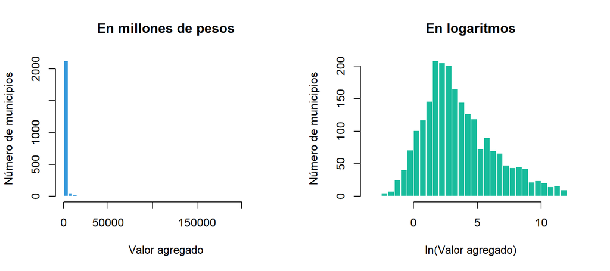

Figura 1: Valor agregado municipal: en niveles y en logaritmos

```r
graf_hist <- function() {
  par(mfrow = c(1, 2))
  hist(datos$Y, breaks = 50, main = "En millones de pesos", xlab = "Valor agregado",
       ylab = "Número de municipios", col = "#3498DB", border = "white")
  hist(log(datos$Y), breaks = 50, main = "En logaritmos", xlab = "ln(Valor agregado)",
       ylab = "Número de municipios", col = "#18BC9C", border = "white")
}
graf_hist()
```

En millones de pesos, casi todos los municipios quedan amontonados cerca de cero y unos pocos se estiran hacia la derecha. En logaritmos la distribución se equilibra. Además, el logaritmo convierte la Cobb-Douglas (una multiplicación) en una suma que se puede estimar por regresión lineal, y permite leer los coeficientes como cambios porcentuales.

## 3.4 La relación entre producción, trabajo y capital

**Qué se hizo.** Se graficó el logaritmo del valor agregado contra el logaritmo del trabajo y del capital, con una línea de tendencia, y se midió la correlación entre trabajo y capital.

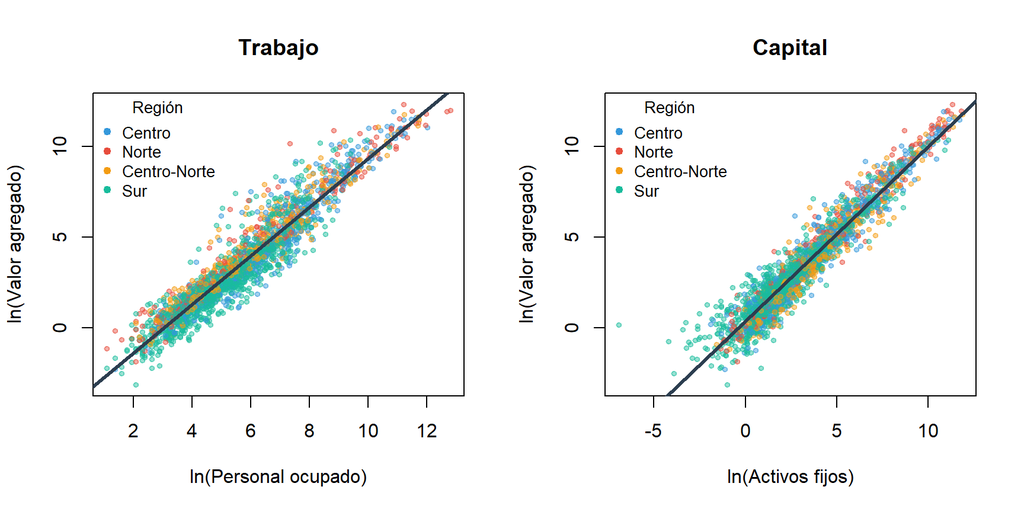

Figura 2: Valor agregado frente a trabajo y capital (en logaritmos). Cada punto es un municipio, coloreado por región; la línea oscura es la tendencia.

```r
datos$lnY <- log(datos$Y)
datos$lnL <- log(datos$L)
datos$lnK <- log(datos$K)

graf_disp <- function() {
  par(mfrow = c(1, 2))
  plot(datos$lnL, datos$lnY, pch = 19, cex = 0.6, col = col_pts, main = "Trabajo",
       xlab = "ln(Personal ocupado)", ylab = "ln(Valor agregado)")
  abline(lm(lnY ~ lnL, data = datos), col = "#2C3E50", lwd = 3)
  leyenda()
  plot(datos$lnK, datos$lnY, pch = 19, cex = 0.6, col = col_pts, main = "Capital",
       xlab = "ln(Activos fijos)", ylab = "ln(Valor agregado)")
  abline(lm(lnY ~ lnK, data = datos), col = "#2C3E50", lwd = 3)
  leyenda()
}
graf_disp()
r_LK <- cor(datos$lnL, datos$lnK)
```

Los puntos siguen una línea recta ascendente: los municipios con más trabajadores y más capital producen más. Esa forma lineal en logaritmos es justo lo que supone el modelo.

Trabajo y capital también están muy relacionados entre sí (correlación de **0.92**): los municipios con más trabajadores suelen tener más maquinaria. Esto hace más difícil separar el efecto de cada uno, pero con 2,273 municipios la estimación es precisa (el factor de inflación de varianza es 6.3, por debajo del límite habitual de 10).

# 4. Modelo 1: Cobb-Douglas

**Temas del parcial:** Regresión lineal múltiple, modelos para medir elasticidad, pruebas de hipótesis, intervalos de confianza

**Qué se hizo.** Se estimó por mínimos cuadrados ordinarios (MCO) la regresión $\ln Y = \beta_0 + \beta_2 \ln L + \beta_3 \ln K + u$. Para cada coeficiente se calculó la prueba t (H0: el coeficiente vale cero), su p-valor y su intervalo de confianza al 95 %. Para el modelo completo se calcularon el R² y la prueba F global (H0: $\beta_2 = \beta_3 = 0$).

```r
m1 <- lm(lnY ~ lnL + lnK, data = datos)

# Función que arma la tabla de resultados de cualquier modelo
tabla_coef <- function(m, nombres) {
  s <- coef(summary(m)); ic <- confint(m, level = 0.95)
  data.frame(Variable = nombres, Coeficiente = fmt(s[, 1], 3), `Error estándar` = fmt(s[, 2], 3),
             t = fmt(s[, 3], 1), `p-valor` = fp(s[, 4]),
             `IC 95 %` = paste0("[", fmt(ic[, 1], 3), ", ", fmt(ic[, 2], 3), "]"),
             check.names = FALSE)
}
```

```r
tab_m1 <- tabla_coef(m1, c("Constante", "ln(Personal ocupado)", "ln(Activos fijos)"))
tabla(tab_m1)
```

Tabla 6: Modelo 1: variable dependiente ln(Valor agregado)

| Variable | Coeficiente | Error estándar | t | p-valor | IC 95 % |
| --- | --- | --- | --- | --- | --- |
| Constante | -1.880 | 0.060 | -31.2 | < 0.001 | [-1.998, -1.762] |
| ln(Personal ocupado) | 0.636 | 0.016 | 39.3 | < 0.001 | [0.604, 0.668] |
| ln(Activos fijos) | 0.549 | 0.012 | 47.5 | < 0.001 | [0.526, 0.571] |

```r
s1 <- summary(m1)
b1 <- coef(m1)
ic1 <- confint(m1)
F1_p <- pf(s1$fstatistic[1], s1$fstatistic[2], s1$fstatistic[3], lower.tail = FALSE)
```

**Cómo leer la tabla**

- **Trabajo (**$\beta_2$ = 0.636): si el personal ocupado aumenta 1 %, el valor agregado aumenta alrededor de 0.636 %, manteniendo igual el capital.
- **Capital (**$\beta_3$ = 0.549): si los activos fijos aumentan 1 %, el valor agregado aumenta alrededor de 0.549 %, manteniendo igual el trabajo.
- **t y p-valor:** el estadístico t indica cuántos errores estándar se aleja el coeficiente de cero (más de 1.96 en valor absoluto ya es significativo al 5 %). Aquí el p-valor es menor que 0.001: ambos efectos son claramente distintos de cero.
- **Intervalo de confianza (IC 95 %):** el rango donde se encuentra, con 95 % de confianza, el valor real de cada coeficiente. Para el trabajo va de 0.604 a 0.668, y para el capital, de 0.526 a 0.571. Son rangos estrechos, así que la estimación es precisa.
- **R² = 0.952:** trabajo y capital explican el **95.2 %** de las diferencias en el logaritmo del valor agregado entre municipios.
- **Prueba F global = 22,655** (p < 0.001): se rechaza que ambos coeficientes sean cero a la vez; el modelo en conjunto es significativo.

# 5. ¿Rendimientos constantes a escala?

**Temas del parcial:** Pruebas de hipótesis, intervalos de confianza

Si $\beta_2 + \beta_3 = 1$, duplicar trabajo y capital duplica exactamente la producción (**rendimientos constantes**). Si la suma es mayor que 1, la producción crece más que proporcionalmente (**rendimientos crecientes**); si es menor, crece menos (**decrecientes**).

**Qué se hizo.** Se contrastó la hipótesis H0: $\beta_2 + \beta_3 = 1$ contra H1: $\beta_2 + \beta_3 \neq 1$ de dos maneras equivalentes (Gujarati y Porter, 2010):

1. **Prueba t sobre la suma**, usando las varianzas y la covarianza de los coeficientes.
2. **Prueba F de mínimos cuadrados restringidos**: se estimó un segundo modelo que *obliga* a que la suma sea 1, $\ln(Y/L) = \beta_0 + \beta_3 \ln(K/L) + u$, y se comparó su suma de errores al cuadrado con la del modelo libre. Si imponer la restricción empeora mucho el ajuste, se rechaza H0.

```r
n <- nobs(m1); k <- length(coef(m1))
b <- coef(m1); V <- vcov(m1)

# Prueba t sobre la suma
suma    <- unname(b["lnL"] + b["lnK"])
ee_suma <- sqrt(V["lnL", "lnL"] + V["lnK", "lnK"] + 2 * V["lnL", "lnK"])
t_crs   <- (suma - 1) / ee_suma
t_crit  <- qt(0.975, df = n - k)

# Prueba F con mínimos cuadrados restringidos
m_r <- lm(I(lnY - lnL) ~ I(lnK - lnL), data = datos)
SCR_NR <- sum(resid(m1)^2)    # suma de errores al cuadrado, modelo libre
SCR_R  <- sum(resid(m_r)^2)   # suma de errores al cuadrado, modelo restringido
F_crs  <- ((SCR_R - SCR_NR) / 1) / (SCR_NR / (n - k))
F_crit <- qf(0.95, 1, n - k)

tabla(data.frame(
  Concepto = c("Suma de elasticidades (β₂ + β₃)", "Error estándar de la suma", "Intervalo de confianza al 95 %",
               "Estadístico t", "Valor crítico de t (5 %)",
               "Suma de errores al cuadrado, sin restricción / con restricción",
               "Estadístico F", "Valor crítico de F (5 %)", "p-valor", "Decisión"),
  Valor = c(fmt(suma, 3), fmt(ee_suma, 3),
            paste0(fmt(suma - t_crit * ee_suma, 3), " a ", fmt(suma + t_crit * ee_suma, 3)),
            fmt(t_crs, 2), fmt(t_crit, 2),
            paste0(fmt(SCR_NR, 2), " / ", fmt(SCR_R, 2)),
            fmt(F_crs, 1), fmt(F_crit, 2),
            fp(pf(F_crs, 1, n - k, lower.tail = FALSE)),
            ifelse(F_crs > F_crit, "Se rechaza H0", "No se rechaza H0"))
))
```

Tabla 7: Prueba de rendimientos constantes a escala (Tabla 4 del artículo)

| Concepto | Valor |
| --- | --- |
| Suma de elasticidades (β₂ + β₃) | 1.185 |
| Error estándar de la suma | 0.007 |
| Intervalo de confianza al 95 % | 1.171 a 1.199 |
| Estadístico t | 25.47 |
| Valor crítico de t (5 %) | 1.96 |
| Suma de errores al cuadrado, sin restricción / con restricción | 830.13 / 1,067.32 |
| Estadístico F | 648.6 |
| Valor crítico de F (5 %) | 3.85 |
| p-valor | < 0.001 |
| Decisión | Se rechaza H0 |

**Conclusión:** la suma de elasticidades es **1.185**, y su intervalo de confianza (1.171 a 1.199) no incluye al 1. Tanto la t (25.47) como la F (648.6) superan por mucho sus valores críticos, así que se rechazan los rendimientos constantes: la manufactura municipal muestra **rendimientos crecientes a escala**.

- Si un municipio **duplica** su personal y su capital, su valor agregado se multiplica por 2^1.185^ = **2.27**, más del doble.
- Si los aumenta **10 %**, su valor agregado crece aproximadamente 12.0 %.
- Al imponer la restricción, la suma de errores al cuadrado sube de 830.13 a 1,067.32: el ajuste empeora bastante.
- Las dos pruebas dan el mismo resultado porque, con una sola restricción, F = t² (648.6 = 25.47²).

# 6. Modelo 2: diferencias entre regiones

**Temas del parcial:** Regresión lineal múltiple, pruebas de hipótesis, intervalos de confianza

¿Un municipio del Norte produce más que uno del Centro con los mismos trabajadores y el mismo capital?

**Qué se hizo.** Se agregaron al modelo tres variables de 0 y 1 (variables dicótomas) para Norte, Centro-Norte y Sur; el Centro es la región de comparación:

$$\ln Y_i = \beta_0 + \beta_2 \ln L_i + \beta_3 \ln K_i + \delta_1 N_i + \delta_2 CN_i + \delta_3 S_i + u_i$$

Cada coeficiente se convirtió a porcentaje con $100 \times (e^{\delta} - 1)$ (Halvorsen y Palmquist, 1980). Con una prueba F se comparó el modelo con y sin regiones (H0: $\delta_1 = \delta_2 = \delta_3 = 0$).

```r
m2 <- lm(lnY ~ lnL + lnK + region, data = datos)
tab_m2 <- tabla_coef(m2, c("Constante", "ln(Personal ocupado)", "ln(Activos fijos)",
                           "Región Norte", "Región Centro-Norte", "Región Sur"))
tabla(tab_m2)
```

Tabla 8: Modelo 2: variable dependiente ln(Valor agregado)

| Variable | Coeficiente | Error estándar | t | p-valor | IC 95 % |
| --- | --- | --- | --- | --- | --- |
| Constante | -1.949 | 0.066 | -29.4 | < 0.001 | [-2.079, -1.819] |
| ln(Personal ocupado) | 0.651 | 0.016 | 39.9 | < 0.001 | [0.619, 0.682] |
| ln(Activos fijos) | 0.533 | 0.012 | 44.8 | < 0.001 | [0.510, 0.556] |
| Región Norte | 0.341 | 0.047 | 7.3 | < 0.001 | [0.249, 0.433] |
| Región Centro-Norte | 0.053 | 0.038 | 1.4 | 0.161 | [-0.021, 0.128] |
| Región Sur | -0.009 | 0.032 | -0.3 | 0.784 | [-0.072, 0.054] |

Para interpretar los coeficientes de región como porcentajes:

```r
idx <- grep("region", names(coef(m2)))
ef  <- coef(summary(m2))[idx, ]
ic2 <- confint(m2)[idx, ]
pct <- function(x) sprintf("%+.1f %%", 100 * (exp(x) - 1))

tabla(data.frame(
  Región = c("Norte", "Centro-Norte", "Sur"),
  `Diferencia frente al Centro` = pct(ef[, 1]),
  `IC 95 %` = paste0("[", pct(ic2[, 1]), ", ", pct(ic2[, 2]), "]"),
  `p-valor` = fp(ef[, 4]),
  Conclusión = ifelse(ef[, 4] < 0.05, "Diferencia significativa", "Sin diferencia significativa"),
  check.names = FALSE
))
```

Tabla 9: Productividad de cada región frente al Centro (a igual trabajo y capital)

| Región | Diferencia frente al Centro | IC 95 % | p-valor | Conclusión |
| --- | --- | --- | --- | --- |
| Norte | +40.6 % | [+28.3 %, +54.1 %] | < 0.001 | Diferencia significativa |
| Centro-Norte | +5.5 % | [-2.1 %, +13.6 %] | 0.161 | Sin diferencia significativa |
| Sur | -0.9 % | [-7.0 %, +5.6 %] | 0.784 | Sin diferencia significativa |

¿Las regiones importan en conjunto? Se compara el Modelo 1 (sin regiones) con el Modelo 2 (con regiones):

```r
a <- anova(m1, m2)
F_reg_crit <- qf(0.95, a$Df[2], a$Res.Df[2])
tabla(data.frame(
  Concepto = c("Restricciones (regiones)", "Estadístico F", "Valor crítico de F (5 %)", "p-valor", "Decisión"),
  Valor = c(fmt(a$Df[2]), fmt(a$F[2], 1), fmt(F_reg_crit, 2), fp(a[["Pr(>F)"]][2]),
            ifelse(a$F[2] > F_reg_crit, "Se rechaza H0: las regiones sí importan", "No se rechaza H0"))
))
```

Tabla 10: Prueba F conjunta de las regiones

| Concepto | Valor |
| --- | --- |
| Restricciones (regiones) | 3 |
| Estadístico F | 21.5 |
| Valor crítico de F (5 %) | 2.61 |
| p-valor | < 0.001 |
| Decisión | Se rechaza H0: las regiones sí importan |

Finalmente, los dos modelos juntos, con el formato de la Tabla 3 del artículo:

```r
s2 <- summary(m2)
est <- function(p) ifelse(p < 0.001, "\\*\\*\\*", ifelse(p < 0.01, "\\*\\*", ifelse(p < 0.05, "\\*", "")))
celda <- function(m, v) {
  s <- coef(summary(m))
  if (!v %in% rownames(s)) return("")
  paste0(fmt(s[v, 1], 3), est(s[v, 4]), " (", fmt(s[v, 2], 3), ")")
}
vars <- c("lnL", "lnK", "regionNorte", "regionCentro-Norte", "regionSur", "(Intercept)")
tabla(data.frame(
  Variable = c("ln Trabajo (β₂)", "ln Capital (β₃)", "Norte", "Centro-Norte", "Sur", "Constante",
               "R²", "Estadístico F", "Observaciones"),
  `Modelo 1` = c(sapply(vars, function(v) celda(m1, v)),
                 fmt(s1$r.squared, 3), fmt(s1$fstatistic[1], 0), fmt(nobs(m1))),
  `Modelo 2` = c(sapply(vars, function(v) celda(m2, v)),
                 fmt(s2$r.squared, 3), fmt(s2$fstatistic[1], 0), fmt(nobs(m2))),
  check.names = FALSE
))
```

Tabla 11: Función Cobb-Douglas (variable dependiente: logaritmo del valor agregado)

| Variable | Modelo 1 | Modelo 2 |
| --- | --- | --- |
| ln Trabajo (β₂) | 0.636*** (0.016) | 0.651*** (0.016) |
| ln Capital (β₃) | 0.549*** (0.012) | 0.533*** (0.012) |
| Norte |  | 0.341*** (0.047) |
| Centro-Norte |  | 0.053 (0.038) |
| Sur |  | -0.009 (0.032) |
| Constante | -1.880*** (0.060) | -1.949*** (0.066) |
| R² | 0.952 | 0.954 |
| Estadístico F | 22,655 | 9,320 |
| Observaciones | 2,273 | 2,273 |

*Errores estándar entre paréntesis. *** p < 0.001; ** p < 0.01; * p < 0.05. Región base: Centro.*

**Conclusión:** la prueba F conjunta (F = 21.5, mayor que su valor crítico de 2.61) indica que las regiones sí importan. Pero la diferencia viene casi toda del **Norte**: sus municipios producen 40.6 % más que los del Centro con los mismos insumos (intervalo de 28.3 % a 54.1 %). Centro-Norte y Sur no se distinguen del Centro. Las elasticidades casi no cambian entre modelos, así que los resultados del Modelo 1 son estables.

Esto también ayuda a entender la sección 3.2: el Sur genera poco valor agregado porque tiene **menos trabajadores y capital**, no porque produzca peor con los mismos insumos.

# 7. Predicciones

**Tema del parcial:** Intervalos de confianza (puntual y promedio)

**Qué se hizo.** Con el Modelo 1 se estimó el valor agregado de dos casos: un municipio con los valores medianos de trabajo y capital, y uno hipotético con 1,000 trabajadores y 500 millones de pesos en activos. Para cada uno se calcularon dos intervalos al 95 %:

- **Intervalo promedio** (de la media): el rango del valor agregado *promedio* de todos los municipios con esas características. Es más estrecho.
- **Intervalo puntual** (individual): el rango del valor agregado de *un* municipio concreto. Es más amplio, porque suma la variación propia de cada municipio.

Las predicciones se obtienen en logaritmos y se regresan a millones de pesos con la función exponencial. Ese valor corresponde a un valor *típico* (la mediana) más que a un promedio estricto.

```r
nuevos <- data.frame(
  caso = c("Municipio mediano", "Caso hipotético"),
  L = c(median(datos$L), 1000),
  K = c(median(datos$K), 500)
)
nuevos$lnL <- log(nuevos$L); nuevos$lnK <- log(nuevos$K)

p_media <- predict(m1, newdata = nuevos, interval = "confidence", level = 0.95)
p_indiv <- predict(m1, newdata = nuevos, interval = "prediction", level = 0.95)

# exp() regresa de logaritmos a millones de pesos
rango <- function(p) paste0(fmt(exp(p[, "lwr"]), 1), " a ", fmt(exp(p[, "upr"]), 1))
tabla_pred <- data.frame(
  Caso = nuevos$caso, Trabajadores = fmt(nuevos$L), `Activos (mdp)` = fmt(nuevos$K, 1),
  Estimado = fmt(exp(p_media[, "fit"]), 1),
  `Intervalo promedio` = rango(p_media), `Intervalo individual` = rango(p_indiv),
  check.names = FALSE
)
tabla(tabla_pred)
```

Tabla 12: Valor agregado estimado (millones de pesos) con intervalos al 95 %

| Caso | Trabajadores | Activos (mdp) | Estimado | Intervalo promedio | Intervalo individual |
| --- | --- | --- | --- | --- | --- |
| Municipio mediano | 233 | 17.3 | 23.4 | 22.8 a 24.0 | 7.1 a 76.5 |
| Caso hipotético | 1,000 | 500.0 | 374.0 | 358.7 a 390.0 | 114.2 a 1,225.3 |

Para un municipio con 233 trabajadores y 17.3 millones de pesos en activos, el valor agregado típico estimado es de **23.4 millones**. El de los municipios con esas características se ubica entre 22.8 y 24.0 millones, mientras que para un municipio en particular el rango va de 7.1 a 76.5 millones. En el caso hipotético, el valor estimado es de 374.0 millones, con un rango individual de 114.2 a 1,225.3 millones.

# 8. Revisión del modelo

**Tema del parcial:** Pruebas de hipótesis (sobre los residuos)

Un modelo es confiable si sus errores (residuos: la diferencia entre el valor real y el estimado) se comportan bien. Se revisan dos aspectos.

## 8.1 Forma de los errores

**Qué se hizo.** Se calcularon la asimetría y la curtosis de los residuos y la prueba de normalidad de Jarque-Bera (H0: los residuos siguen una distribución normal). También se graficaron los residuos.

```r
e  <- resid(m1)
S  <- mean((e - mean(e))^3) / mean((e - mean(e))^2)^(3/2)   # asimetría
Ku <- mean((e - mean(e))^4) / mean((e - mean(e))^2)^2       # curtosis
JB <- n * (S^2 / 6 + (Ku - 3)^2 / 24)

tabla(data.frame(
  Medida = c("Asimetría (ideal: 0)", "Curtosis (ideal: 3)", "Estadístico Jarque-Bera", "p-valor"),
  Valor = c(fmt(S, 2), fmt(Ku, 2), fmt(JB, 1), fp(pchisq(JB, 2, lower.tail = FALSE)))
))
```

Tabla 13: Prueba de normalidad de los residuos (Jarque-Bera)

| Medida | Valor |
| --- | --- |
| Asimetría (ideal: 0) | 0.91 |
| Curtosis (ideal: 3) | 5.59 |
| Estadístico Jarque-Bera | 946.1 |
| p-valor | < 0.001 |

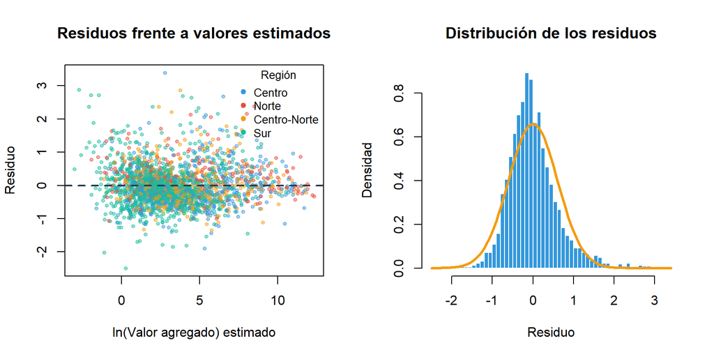

Figura 3: Residuos del Modelo 1. A la izquierda, cada punto es un municipio coloreado por región; a la derecha, la curva naranja es la distribución normal de referencia.

```r
graf_res <- function() {
  par(mfrow = c(1, 2))
  plot(fitted(m1), e, pch = 19, cex = 0.6, col = col_pts, main = "Residuos frente a valores estimados",
       xlab = "ln(Valor agregado) estimado", ylab = "Residuo")
  abline(h = 0, lty = 2, col = "#2C3E50", lwd = 2)
  leyenda("topright")
  hist(e, breaks = 50, freq = FALSE, main = "Distribución de los residuos", xlab = "Residuo",
       ylab = "Densidad", col = "#3498DB", border = "white")
  curve(dnorm(x, mean(e), sd(e)), add = TRUE, col = "#F39C12", lwd = 3)
}
graf_res()
```

Los residuos no son perfectamente “normales”: tienen una cola larga hacia la derecha (asimetría 0.91) y más valores extremos de lo esperado (curtosis 5.59), por lo que la prueba rechaza la normalidad. Con 2,273 municipios esto no invalida los coeficientes ni sus pruebas (Gujarati y Porter, 2010), pero sí hace que los **rangos para un municipio individual** de la sección anterior sean solo aproximados.

## 8.2 ¿Los errores tienen la misma dispersión en todos los municipios?

**Qué se hizo.** Se dividieron los municipios en cuatro grupos según su número de trabajadores y se comparó la dispersión de los residuos en cada grupo. Después se aplicó la prueba de White (H0: la varianza de los errores es la misma en todos los municipios) y, como comprobación, se recalcularon los errores estándar con el método robusto de White (1980), que no depende de ese supuesto.

```r
cuarto <- cut(datos$L, quantile(datos$L, 0:4 / 4), include.lowest = TRUE,
              labels = c("25 % más pequeño", "Segundo cuarto", "Tercer cuarto", "25 % más grande"))
tabla(data.frame(
  `Tamaño del municipio (por personal ocupado)` = levels(cuarto),
  Municipios = fmt(as.numeric(table(cuarto))),
  `Desviación estándar de los residuos` = fmt(tapply(e, cuarto, sd), 3),
  check.names = FALSE
))
```

Tabla 14: Dispersión de los residuos según el tamaño del municipio

| Tamaño del municipio (por personal ocupado) | Municipios | Desviación estándar de los residuos |
| --- | --- | --- |
| 25 % más pequeño | 574 | 0.664 |
| Segundo cuarto | 563 | 0.555 |
| Tercer cuarto | 568 | 0.593 |
| 25 % más grande | 568 | 0.598 |

```r
aux  <- lm(I(e^2) ~ lnL + lnK + I(lnL^2) + I(lnK^2) + I(lnL * lnK), data = datos)
LM_w <- n * summary(aux)$r.squared
gl_w <- length(coef(aux)) - 1
tabla(data.frame(
  Concepto = c("Estadístico (n × R²)", "Grados de libertad", "p-valor", "Decisión"),
  Valor = c(fmt(LM_w, 1), fmt(gl_w), fp(pchisq(LM_w, gl_w, lower.tail = FALSE)),
            ifelse(pchisq(LM_w, gl_w, lower.tail = FALSE) < 0.05,
                   "Se rechaza H0: la dispersión no es igual", "No se rechaza H0"))
))
```

Tabla 15: Prueba de White de heterocedasticidad

| Concepto | Valor |
| --- | --- |
| Estadístico (n × R²) | 147.6 |
| Grados de libertad | 5 |
| p-valor | < 0.001 |
| Decisión | Se rechaza H0: la dispersión no es igual |

```r
X     <- model.matrix(m1)
XtXi  <- solve(t(X) %*% X)
V_rob <- XtXi %*% (t(X * e^2) %*% X) %*% XtXi * n / (n - k)
ee_rob <- sqrt(diag(V_rob))
t_rob  <- (suma - 1) / sqrt(V_rob[2, 2] + V_rob[3, 3] + 2 * V_rob[2, 3])

tabla(data.frame(
  Variable = c("Constante", "ln(Personal ocupado)", "ln(Activos fijos)"),
  Coeficiente = fmt(coef(m1), 3),
  `Error estándar habitual` = fmt(sqrt(diag(vcov(m1))), 3),
  `Error estándar robusto` = fmt(ee_rob, 3),
  check.names = FALSE
))
```

Tabla 16: Errores estándar habituales y robustos (Modelo 1)

| Variable | Coeficiente | Error estándar habitual | Error estándar robusto |
| --- | --- | --- | --- |
| Constante | -1.880 | 0.060 | 0.074 |
| ln(Personal ocupado) | 0.636 | 0.016 | 0.022 |
| ln(Activos fijos) | 0.549 | 0.012 | 0.017 |

# 9. Conclusiones

1. **Trabajo y capital explican casi toda la producción municipal.** El modelo explica el 95.2 % de las diferencias en el logaritmo del valor agregado.
2. **El trabajo pesa algo más que el capital.** Un aumento de 1 % en el personal eleva el valor agregado 0.636 %; uno de 1 % en los activos fijos, 0.549 %.
3. **Hay rendimientos crecientes a escala.** La suma de elasticidades es 1.185 y es estadísticamente mayor que 1: duplicar los insumos multiplica la producción por 2.27.
4. **El Norte es más productivo.** A igual trabajo y capital, produce 40.6 % más que el Centro. Centro-Norte y Sur no difieren del Centro.
5. **Predicción.** Un municipio típico genera unos 23.4 millones de pesos de valor agregado; el promedio se estima con precisión, pero un municipio en particular puede variar mucho.
6. **Cautelas.** Los resultados son asociaciones de un solo año (2023), no efectos causales. Se excluyeron 178 municipios con actividad manufacturera por falta de datos. Los rendimientos crecientes pueden reflejar también que los municipios grandes concentran industrias con más valor agregado por trabajador, algo que este modelo no separa.